# Common plots in ggplot2

The type of plot created depends on a few factors:

- the type of variable(s) being displayed,
- and the number of variables being displayed.

Today we’ll learn more about creating specific types of plots using the `ggplot2` package.

To begin, load the `tidyverse`:

```r
library(tidyverse)
```

Further, to ground our discussion, let’s consider the `diamonds` data set that is loaded with the `tidyverse`.

```r
head(diamonds)
```

| carat | cut | color | clarity | depth | table | price | x | y | z |
| --- | --- | --- | --- | --- | --- | --- | --- | --- | --- |
| 0.23 | Ideal | E | SI2 | 61.5 | 55 | 326 | 3.95 | 3.98 | 2.43 |
| 0.21 | Premium | E | SI1 | 59.8 | 61 | 326 | 3.89 | 3.84 | 2.31 |
| 0.23 | Good | E | VS1 | 56.9 | 65 | 327 | 4.05 | 4.07 | 2.31 |
| 0.29 | Premium | I | VS2 | 62.4 | 58 | 334 | 4.20 | 4.23 | 2.63 |
| 0.31 | Good | J | SI2 | 63.3 | 58 | 335 | 4.34 | 4.35 | 2.75 |
| 0.24 | Very Good | J | VVS2 | 62.8 | 57 | 336 | 3.94 | 3.96 | 2.48 |

**Question.** How how many observations are in the diamonds data set?

For information about the variable definitions, see the help file using `?diamonds` in the console.

# Univariate graphics

### Histograms

**Use:** exploring the distribution of a quantitative variable

**geometry:** `geom_histogram`

**aesthetics required**: `x` (the variable to be displayed)

```r
# Histogram of carat
diamonds %>%
  ggplot(aes(x = carat)) +
  geom_histogram()
```

**Remember to check the binwidth!**

### Density plots

**Use:** exploring the distribution of a quantitative variable

**geometry:** `geom_density`

**aesthetics required**: `x` (the variable to be displayed)

```r
# Density plot of price
diamonds %>%
  ggplot(aes(x = price)) +
  geom_density()
```

### Bar charts

**Use:** exploring the distribution of a categorical variable

**geometry:** `geom_bar`

**aesthetics required**: `x` (the variable to be displayed)

```r
# Bar chart of clarity
diamonds %>%
  ggplot(aes(x = clarity)) +
  geom_bar()
```

# Bivariate graphics

### Scatterplots

**Use:** exploring the relationship between two quantitative variables

**geometry:** `geom_point`

**aesthetics required**: `x`, `y`

```r
# Let's see how carat and price are related
diamonds %>%
  ggplot(aes(x = carat, y = price)) +
  geom_point()
```

But that’s pretty hard to read because we’re plotting so many points!

```r
# Set the alpha level to help with overplotting
diamonds %>%
  ggplot(aes(x = carat, y = price)) +
  geom_point(alpha = 0.1)
```

We can also add a smoother to reveal the trend in the scatterplot

```r
# Add a smoother to the plot above
diamonds %>%
  ggplot(aes(x = carat, y = price)) +
  geom_point(alpha = 0.1) +
  geom_smooth()
```

### Segmented bar chart

**Use:** exploring the relationship between two categorical variables

**geometry:** `geom_bar`

**aesthetics required**: `x`, `fill`

[figure not shown]

It’s also interesting to set the `position`.

```r
# create a segmented bar chart of  clarity by color, setting position = "fill"
diamonds %>%
  ggplot(aes(x = clarity, fill = color)) +
  geom_bar(position = "fill")
```

```r
# create a segmented bar chart of  clarity by color, setting position = "dodge"
diamonds %>%
  ggplot(aes(x = clarity, fill = color)) +
  geom_bar(position = "dodge")
```

### Side-by-side boxplots

**Use:** exploring the relationship between a quantitative and categorical variable

**geometry:** `geom_boxplot`

**aesthetics required**: `x` (categorical), `y` (quantitative)

```r
# create boxplots of price by cut
diamonds %>%
  ggplot(aes(x = cut, y = price)) +
  geom_boxplot()
```

```r
# Let's try adding the points on top of the boxplots
diamonds %>%
  ggplot(aes(x = cut, y = price)) +
  geom_boxplot() +
  geom_point()
```

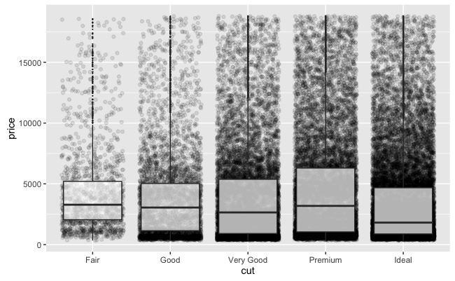

```r
# Let's try again with geom_jitter
# we'll need to eliminate the outliers in the boxplots by setting
#   outlier.size=0
diamonds %>%
  ggplot(aes(x = cut, y = price)) +
  geom_jitter(alpha = 0.1) +
  geom_boxplot(outlier.size=0, alpha = 0.7)
```

# Adding in more variables

To add additional variables we can use **aesthetics** such as

- size
- color
- fill
- shape

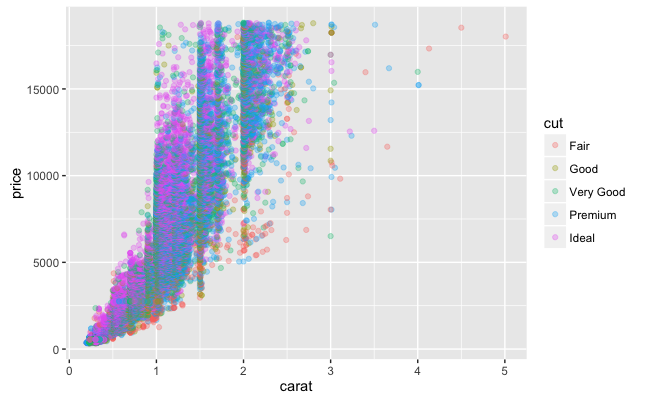

```r
# Let's look at whether adding color for cut tells us anything about
# the relationship between carat and price
diamonds %>%
  ggplot(aes(x = carat, y = price, color = cut)) +
  geom_point(alpha = 0.3)
```

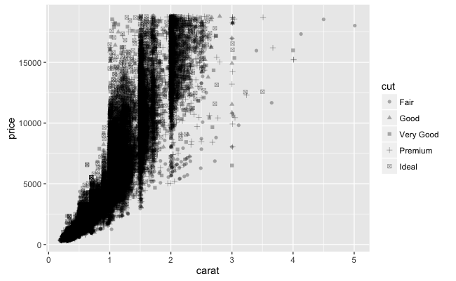

```r
# Would shape be a better aesthetic to use?
diamonds %>%
  ggplot(aes(x = carat, y = price, shape = cut)) +
  geom_point(alpha = 0.3)
```

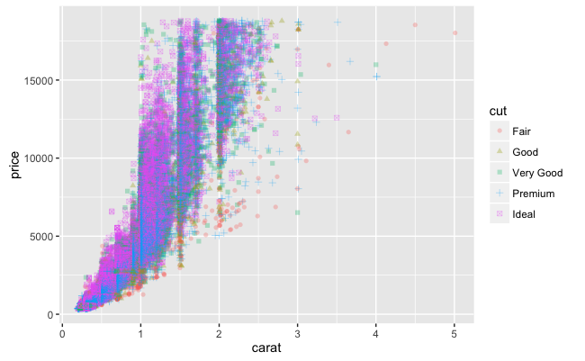

```r
# Would be using both color and shape better?
diamonds %>%
  ggplot(aes(x = carat, y = price, color = cut, shape = cut)) +
  geom_point(alpha = 0.3)
```

Alternatively, we can use **facetting**.

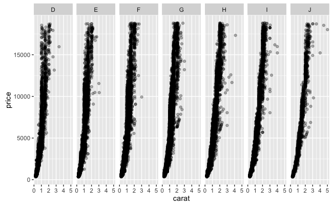

```r
# Let's facet the scatterplot of price vs. carat by color
diamonds %>%
  ggplot(aes(x = carat, y = price)) +
  geom_point(alpha = 0.3) +
  facet_wrap(~color, nrow = 1)
```

```r
# Let's facet the scatterplot of price vs. carat by color AND clarity
diamonds %>%
  ggplot(aes(x = carat, y = price)) +
  geom_point(alpha = 0.1) +
  facet_grid(color~clarity)
```

# Exercise

In this exercise, we investigate home prices in Saratoga County, New York. The data set `saratoga.csv` contains the prices of 1,728 homes.

To begin, load the data set.

```r
# SOLUTION
```

1. Describe the distribution of `Price`.

```r
# SOLUTION
```

2. Are houses with fireplaces generally more expensive than houses without?

```r
# SOLUTION
```

3. Describe the relationship between Price and Living Area.

```r
# SOLUTION
```

4. Update the plot you created in part 3 to include whether information about whether the house has a fireplace. Summarize your findings.

```r
# SOLUTION
```